# KNN: Finding Optimal K

Collin Fabian

2/24/2021

## Problem 1

Below we can see the data as well as the Euclidean Distance of each point from the new data, which all match our R output.

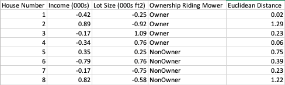

**1.A**  
Now we can run our first KNN test with K=5

```r
test.df = data.frame(-0.4, 0.4)
nn5 <- knn(train = mowers[, 2], test = test.df[1],
          cl = mowers[, 4], k = 5, prob = TRUE)
nn5
```

```
## [1] Owner
## attr(,"prob")
## [1] 0.6
## attr(,"nn.index")
##      [,1] [,2] [,3] [,4] [,5]
## [1,]    1    4    3    7    6
## attr(,"nn.dist")
##      [,1] [,2] [,3] [,4] [,5]
## [1,] 0.02 0.06 0.23 0.23 0.39
## Levels: Owner
```

As we can see, the probability of the new data point being a riding mower owner is 0.6, or 60%. The probability of the new data point not being a riding mower owner is 0.4, or 40%. Therefore, I would classify the new point as a riding mower owner.  
**1.B**  
Now we will run our next KNN test with K=3

```r
nn3 <- knn(train = mowers[, 3], test = test.df[2],
          cl = mowers[, 4], k = 3, prob = TRUE)
nn3
```

```
## [1] NonOwner
## attr(,"prob")
## [1] 0.6666667
## attr(,"nn.index")
##      [,1] [,2] [,3]
## [1,]    5    6    4
## attr(,"nn.dist")
##      [,1] [,2] [,3]
## [1,] 0.15 0.36 0.36
## Levels: NonOwner
```

As we can see, the probability of the new data point being a riding mower owner is about 0.3333, or 33.33%. The probability of the new data point not being a riding mower owner is about 0.6666, or 66.66%%. Therefore, I would classify the new point as a NON riding mower owner.  
**1.C**  
Now we will run our next KNN test with K=7

```r
nn7 <- knn(train = mowers[, 2:3], test = test.df[],
          cl = mowers[, 4], k = 7, prob = TRUE)
nn7
```

```
## [1] NonOwner
## attr(,"prob")
## [1] 0.5714286
## attr(,"nn.index")
##      [,1] [,2] [,3] [,4] [,5] [,6] [,7]
## [1,]    4    6    1    3    5    7    8
## attr(,"nn.dist")
##           [,1]      [,2]      [,3]      [,4]      [,5]     [,6]     [,7]
## [1,] 0.3649658 0.5307542 0.6503076 0.7273239 0.7648529 1.172774 1.564864
## Levels: NonOwner
```

As we can see, the probability of the new data point being a riding mower owner is about 0.4286, or 42.86%. The probability of the new data point not being a riding mower owner is about 0.5714, or 57.14%. Therefore, I would classify the new point as NOT a riding mower owner.

## Problem 2

First we must subset our data so that we are left only with the desired columns.

```r
myvars <- c('Age', 'Experience', 'Income', 'Family', 'CCAvg', 'Mortgage', 'Personal.Loan')
bank <- bank[myvars]
bank <- bank %>%
  mutate(Personal.Loan = recode(Personal.Loan,
                      "0" = "Reject",
                      "1" = "Accept"))
head(bank)
```

|  | Age | Experience | Income | Family | CCAvg | Mortgage | Personal.Loan |
| --- | --- | --- | --- | --- | --- | --- | --- |
| 1 | 25 | 1 | 49 | 4 | 1.6 | 0 | Reject |
| 2 | 45 | 19 | 34 | 3 | 1.5 | 0 | Reject |
| 3 | 39 | 15 | 11 | 1 | 1.0 | 0 | Reject |
| 4 | 35 | 9 | 100 | 1 | 2.7 | 0 | Reject |
| 5 | 35 | 8 | 45 | 4 | 1.0 | 0 | Reject |
| 6 | 37 | 13 | 29 | 4 | 0.4 | 155 | Reject |

**2.A + 2.B**  
In this instance we will perform multiple KNN tests varying our K-value each time. We will run each KNN test five times and calculate the mis-classification rate of each one. From there we will calculate the average mis-classification rate and record all 6 values for each KNN test.

```r
Ks <- c(1, 3, 5, 7, 9)
seed.val <- c(111,121,131,141,151)
L <- length(seed.val)
classrate_vec <- matrix(0,L)

first <- c()
second <- c()
third <- c()
fourth <- c()
fifth <- c()
avg <- c()

for (i in Ks){
  MisClassRates = c()
  for (l in 1:L){

    set.seed(seed.val[l])
    train.index <- sample(row.names(bank), 0.8*dim(bank)[1])
    valid.index <- setdiff(row.names(bank), train.index)
    train.df <- bank[train.index, ]
    valid.df <- bank[valid.index, ]

    norm.values <- preProcess(train.df[, 1:6], method=c("center", "scale"))
    train.df.norm <- predict(norm.values, train.df[, 1:6])
    valid.df.norm <- predict(norm.values, valid.df[, 1:6])
    nn <- knn(train = train.df.norm[, 1:6], test = valid.df.norm[, 1:6],
                cl = train.df[, 7], k = i)
    x <- as.character(nn)

    ConfusMatrix <- table(x, valid.df[, 7])
    print(ConfusMatrix)
    table_dim <- dim(ConfusMatrix)

    classrate_vec[l] <- (ConfusMatrix[2,"Accept"] + ConfusMatrix[1, "Reject"])/1000
    cat('Mis-Classification Rate:', classrate_vec[l])
    MisClassRates <- append(MisClassRates, classrate_vec[l])

  }
  MisClassAvg <- mean(classrate_vec)
  K <- append(MisClassRates, MisClassAvg)

  first <- append(first, K[1])
  second <- append(second, K[2])
  third <- append(third, K[3])
  fourth <- append(fourth, K[4])
  fifth <- append(fifth, K[5])
  avg <- append(avg, K[6])
}
```

```
##
## x        Accept Reject
##   Accept     59     17
##   Reject     40    884
## Mis-Classification Rate: 0.057
## x        Accept Reject
##   Accept     54     23
##   Reject     42    881
## Mis-Classification Rate: 0.065
## x        Accept Reject
##   Accept     62     16
##   Reject     30    892
## Mis-Classification Rate: 0.046
## x        Accept Reject
##   Accept     51     17
##   Reject     33    899
## Mis-Classification Rate: 0.05
## x        Accept Reject
##   Accept     58     14
##   Reject     44    884
## Mis-Classification Rate: 0.058
## x        Accept Reject
##   Accept     52     13
##   Reject     47    888
## Mis-Classification Rate: 0.06
## x        Accept Reject
##   Accept     47     12
##   Reject     49    892
## Mis-Classification Rate: 0.061
## x        Accept Reject
##   Accept     56     13
##   Reject     36    895
## Mis-Classification Rate: 0.049
## x        Accept Reject
##   Accept     43     11
##   Reject     41    905
## Mis-Classification Rate: 0.052
## x        Accept Reject
##   Accept     48      4
##   Reject     54    894
```

[output cut: 46 more lines]

```
##   Accept     39      6
##   Reject     57    898
## Mis-Classification Rate: 0.063
## x        Accept Reject
##   Accept     43      6
##   Reject     49    902
## Mis-Classification Rate: 0.055
## x        Accept Reject
##   Accept     36      4
##   Reject     48    912
## Mis-Classification Rate: 0.052
## x        Accept Reject
##   Accept     42     11
##   Reject     60    887
## Mis-Classification Rate: 0.071
```

Below are the mis-classification rates and their average of all the K-values of our various KNN tests.

```r
output.df <- data.frame(first, second, third, fourth, fifth, avg,
                        row.names = Ks)
output.df
```

|  | first | second | third | fourth | fifth | avg |
| --- | --- | --- | --- | --- | --- | --- |
| 1 | 0.057 | 0.065 | 0.046 | 0.050 | 0.058 | 0.0552 |
| 3 | 0.060 | 0.061 | 0.049 | 0.052 | 0.058 | 0.0560 |
| 5 | 0.059 | 0.060 | 0.044 | 0.052 | 0.059 | 0.0548 |
| 7 | 0.058 | 0.062 | 0.055 | 0.050 | 0.065 | 0.0580 |
| 9 | 0.060 | 0.063 | 0.055 | 0.052 | 0.071 | 0.0602 |

**2.C**  
Based on our results, I found that the K=5 is the optimal K-value to reduce the average mis-classification rate due to the fact that it’s was the lowest.  
**2.D**

```r
new_customer = data.frame(40, 10, 84, 2, 2, 0)
nn <- knn(train = train.df[, 1:6], test = new_customer[, 1:6],
                cl = train.df[, 7], k = 5, prob = TRUE)
nn
```

```
## [1] Reject
## attr(,"prob")
## [1] 1
## attr(,"nn.index")
##      [,1] [,2] [,3] [,4] [,5]
## [1,] 1942 2248 3081  843 2565
## attr(,"nn.dist")
##          [,1]     [,2]     [,3]     [,4]     [,5]
## [1,] 3.168596 3.746999 4.317407 4.323193 4.323193
## Levels: Reject
```

**2.E**  
Based on our results, the probability that the loan will be accepted is 0, or 0%. However, the probability that the loan will be rejected is 1, or 100%. So, given the customer, it is very unlikely that the loan will be accepted. Since our average classification rate for K=5 is 0.0548, we know that only about 5.5% of the predictions made are false. Thus, we can assume that the true probability of the customer rejecting the loan is somewhere in the range of **(0.9452, 1)**. Therefore, the liklihood of the given customer accepting the loan is very unlikely.